# Prediction Assignment Write-up

Dominique Loete

30 januari 2016

### Exploratory Data Analysis

This project requires the prediction of the quality of weight lifting action based on data gathered from test subjects (ref. 1). To do this prediction consistently, I not only load the required libraries, but also set the seed to a fixed number, namely 323.

```r
options(warn=-1)
library(foreach)
library(caret)
library(ggplot2)
library(randomForest)
library(gbm)
library(doParallel)
library(plyr)
library(rpart)
library(rpart.plot)
library(corrplot)
set.seed(323)
```

Download the data:

```r
trainUrl <-"https://d396qusza40orc.cloudfront.net/predmachlearn/pml-training.csv"
testUrl <- "https://d396qusza40orc.cloudfront.net/predmachlearn/pml-testing.csv"
trainFile <- "./data/pml-training.csv"
testFile  <- "./data/pml-testing.csv"
if (!file.exists("./data")) {
  dir.create("./data")
}
if (!file.exists(trainFile)) {
  download.file(trainUrl, destfile=trainFile, method="curl")
}
if (!file.exists(testFile)) {
  download.file(testUrl, destfile=testFile, method="curl")
}
```

Next step is the loading of the data. The data is present in the directory *data* and contains some strings “#DIV/0!”, which need to be altered to *NA* values:

```r
raw_training_data <- read.csv("./data/pml-training.csv", na.strings = "#DIV/0!", row.names = 1)
raw_evaluation_data <- read.csv("./data/pml-testing.csv", na.strings = "#DIV/0!", row.names = 1)
dim(raw_training_data)
```

```
## [1] 19622   159
```

```r
dim(raw_evaluation_data)
```

```
## [1]  20 159
```

So 19622 observations of 159 variables with *classe* being the outcome. And 20 test samples where the *classe* needs to be predicted.

### Data cleaning

The training dataset contains a lot of variables, and also many NA values for those variables. So first step will be to clean up the dataset by removing near zero covariates and variables which have missing values, since they will have very little use in the prediction model.

```r
training_data <- raw_training_data[, colSums(is.na(raw_training_data)) == 0]
evaluation_data <- raw_evaluation_data[, colSums(is.na(raw_evaluation_data)) == 0]
nsv <- nearZeroVar(training_data, saveMetrics = TRUE)
training_data <- training_data[, !nsv$nzv]
evaluation_data <- evaluation_data[, !nsv$nzv]
names(training_data)
```

```
##  [1] "user_name"            "raw_timestamp_part_1" "raw_timestamp_part_2"
##  [4] "cvtd_timestamp"       "num_window"           "roll_belt"
##  [7] "pitch_belt"           "yaw_belt"             "total_accel_belt"
## [10] "gyros_belt_x"         "gyros_belt_y"         "gyros_belt_z"
## [13] "accel_belt_x"         "accel_belt_y"         "accel_belt_z"
## [16] "magnet_belt_x"        "magnet_belt_y"        "magnet_belt_z"
## [19] "roll_arm"             "pitch_arm"            "yaw_arm"
## [22] "total_accel_arm"      "gyros_arm_x"          "gyros_arm_y"
## [25] "gyros_arm_z"          "accel_arm_x"          "accel_arm_y"
## [28] "accel_arm_z"          "magnet_arm_x"         "magnet_arm_y"
## [31] "magnet_arm_z"         "roll_dumbbell"        "pitch_dumbbell"
## [34] "yaw_dumbbell"         "total_accel_dumbbell" "gyros_dumbbell_x"
## [37] "gyros_dumbbell_y"     "gyros_dumbbell_z"     "accel_dumbbell_x"
## [40] "accel_dumbbell_y"     "accel_dumbbell_z"     "magnet_dumbbell_x"
## [43] "magnet_dumbbell_y"    "magnet_dumbbell_z"    "roll_forearm"
## [46] "pitch_forearm"        "yaw_forearm"          "total_accel_forearm"
## [49] "gyros_forearm_x"      "gyros_forearm_y"      "gyros_forearm_z"
## [52] "accel_forearm_x"      "accel_forearm_y"      "accel_forearm_z"
## [55] "magnet_forearm_x"     "magnet_forearm_y"     "magnet_forearm_z"
## [58] "classe"
```

The non-usable variables for prediction should also be removed from the training and evaluation set, so those are the timestamps, usernames and num_window. And all columns apart from *classe* should be numeric.

```r
training_data <- training_data[,-(1:5)]
for(i in c(2:ncol(training_data)-1)) {training_data[,i] = as.numeric(as.character(training_data[,i]))}
evaluation_data <- evaluation_data[,-(1:5)]
for(i in c(2:ncol(evaluation_data)-1)) {evaluation_data[,i] = as.numeric(as.character(evaluation_data[,i]))}
dim(training_data)
```

```
## [1] 19622    53
```

```r
cor_test <- training_data
cor_test$classe <- as.numeric(cor_test$classe)
cor.mtest <- function(mat, ...) {
    mat <- as.matrix(mat)
    n <- ncol(mat)
    p.mat<- matrix(NA, n, n)
    diag(p.mat) <- 0
    for (i in 1:(n - 1)) {
        for (j in (i + 1):n) {
            tmp <- cor.test(mat[, i], mat[, j], ...)
            p.mat[i, j] <- p.mat[j, i] <- tmp$p.value
        }
    }
    colnames(p.mat) <- rownames(p.mat) <- colnames(mat)
    p.mat
}
p.mat <- cor.mtest(cor_test)
cor_predictors <- p.mat[53,p.mat[53,] > 0.05]
```

```r
names(cor_predictors)
```

```
##  [1] "pitch_belt"        "yaw_belt"          "gyros_belt_x"
##  [4] "accel_belt_x"      "accel_belt_y"      "gyros_arm_x"
##  [7] "gyros_arm_z"       "yaw_dumbbell"      "gyros_dumbbell_x"
## [10] "gyros_dumbbell_z"  "magnet_dumbbell_y" "gyros_forearm_y"
## [13] "gyros_forearm_z"   "accel_forearm_z"
```

The rest is removed from the datasets.

```r
training_data <- training_data[,c(names(cor_predictors),"classe")]
evaluation_data <- evaluation_data[,c(names(cor_predictors),"problem_id")]
```

This leaves a training dataset with 14 predictors and the outcome *classe*. The training dataset looks to be ready for the creation of our prediction model.

### Building prediction model

I divide the training dataset into an actual training set (60% of the dataset) and an validation set (40% of the observations). After I am happy with my prediction model, I will use it to predict on the given *testing* dataset as evaluation for Coursera.

```r
inTrain <- createDataPartition(y=training_data$classe, p=0.6, list=FALSE)
training <- training_data[inTrain,]
testing <- training_data[-inTrain,]
```

The plan is to try a few different models and see which gives a good enough performance of accuracy. If it turns out we don’t reach ~99% accuracy with just a single model, then a combination will be tried. In an attempt to minimize overfitting, I will use a 10-fold cross-validation in the models. The models will be run in parallel to speed up the fitting.

```r
cl <- makeCluster(detectCores(), type='PSOCK')
registerDoParallel(cl)
mod_gbm <- train(classe ~ . , method = "gbm", data = training,
                 trControl = trainControl(method = "cv", number = 10))
registerDoSEQ()
cl <- makeCluster(detectCores(), type='PSOCK')
registerDoParallel(cl)
mod_rf <- train(classe ~ . , method = "rf", data = training, importance = TRUE,
                trControl = trainControl(method = "cv", number = 10))
registerDoSEQ()
```

I chose to try a boosting model (**gbm**) and use the **random forest** model. The performance of those models, that is the In-Sample Error Rate (*1-accuracy*):

```r
test_gbm <- predict(mod_gbm, training)
test_rf <- predict(mod_rf, training)
confusionMatrix(test_gbm,training$classe)$overall[c(1,3,4)]
```

```
##      Accuracy AccuracyLower AccuracyUpper
##     0.9014096     0.8958833     0.9067367
```

```r
confusionMatrix(test_rf, training$classe)$overall[c(1,3,4)]
```

```
##      Accuracy AccuracyLower AccuracyUpper
##     1.0000000     0.9996868     1.0000000
```

### Testing prediction model

Now the model should be tested. And hopefully the Out-of-Sample Error Rate is also good.

```r
pred_rf <- predict(mod_rf, testing)
confusionMatrix(pred_rf,testing$classe)$overall[c(1,3,4)]
```

```
##      Accuracy AccuracyLower AccuracyUpper
##     0.9794800     0.9760953     0.9825016
```

### Prediction Test data

The last step is predicting the outcomes of the twenty test samples:

```r
pred_eval <- predict(mod_rf, evaluation_data)
pred_eval
```

```
##  [1] B A B A A E D B A A B C B A E E A B B B
## Levels: A B C D E
```

These prediction will be submitted to the *Course Project Prediction Quiz* for grading.

### References

[1]: [Velloso, E.; Bulling, A.; Gellersen, H.; Ugulino, W.; Fuks, H. Qualitative Activity Recognition of Weight Lifting Exercises. Proceedings of 4th International Conference in Cooperation with SIGCHI (Augmented Human ’13) . Stuttgart, Germany: ACM SIGCHI, 2013.

Read more: http://groupware.les.inf.puc-rio.br/har#ixzz3yjdCJ4dS](http://groupware.les.inf.puc-rio.br/har)

### Appendix

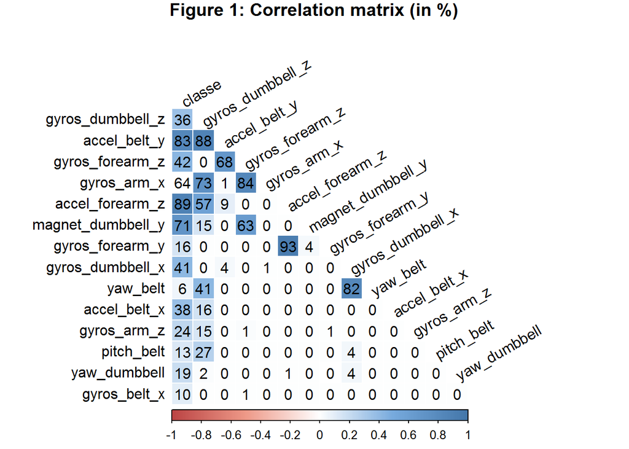

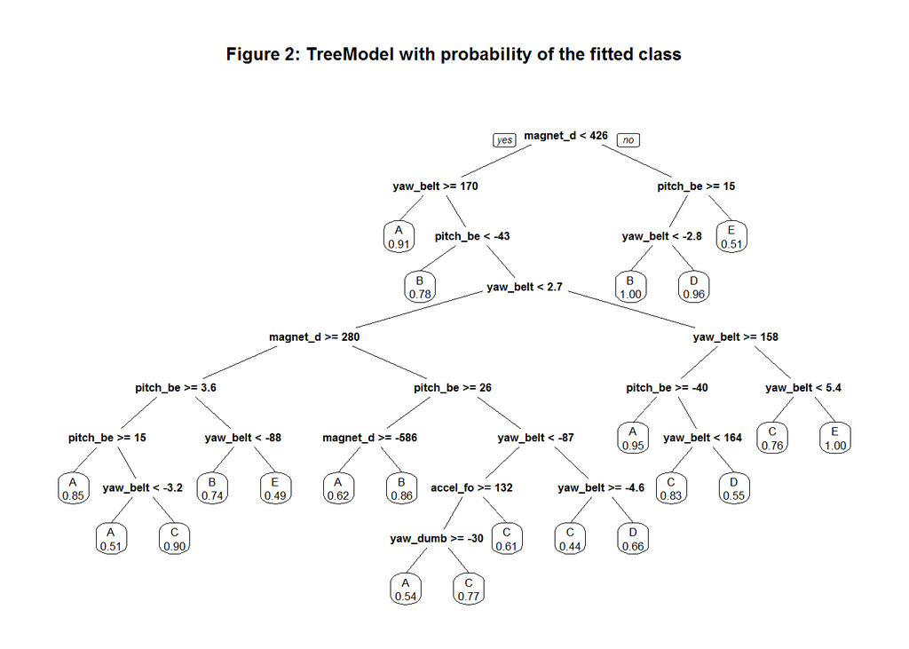